# 6강 재현성 있는 문서작성

## 2.2 Run 설정

> Run Selected Line 을 주로 사용

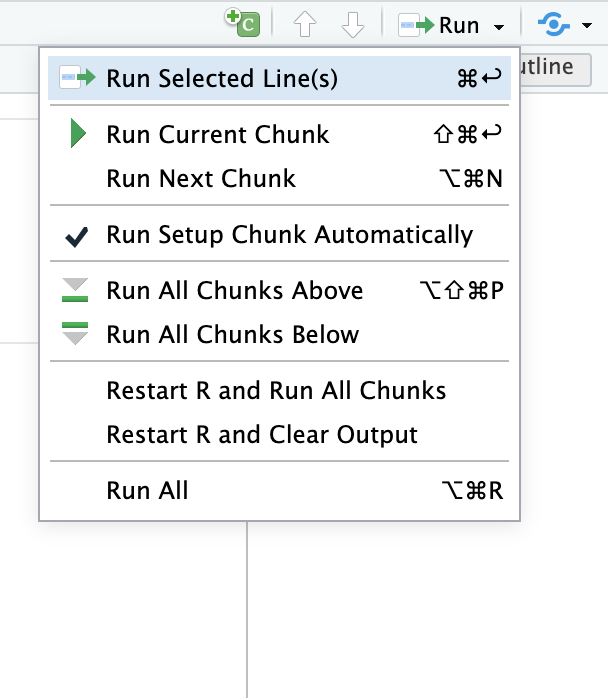

Run 설정

# 3 chunk

## 3.1 청크 옵션(Chunk Option)

> code 블록에 적용하는 다양한 특수 설정들

> 코드 블록에서만 동작하며 반드시 줄간격 없이 입력해야 함

| **옵션** | **코드 실행** | **코드 표시** | **출력** | **그래프** | **메시지** | **경고** |
| --- | --- | --- | --- | --- | --- | --- |
| `eval: false` | **X** |  | **X** | **X** | **X** | **X** |
| `include: false` |  | **X** | **X** | **X** | **X** | **X** |
| `echo: false` |  | **X** |  |  |  |  |
| `results: hide` |  |  | **X** |  |  |  |
| `fig-show: hide` |  |  |  | **X** |  |  |
| `message: false` |  |  |  |  | **X** |  |
| `warning: false` |  |  |  |  |  | **X** |

## 3.2 `eval: false` (코드 실행 안 함)

> 코드가 문서에 그대로 **표시만 되고 실행은 되지 않습니다.** 당연히 그래프나 결과 출력도 없습니다.

```r
penguins
```

## 3.3 `echo: false` (코드만 숨김)

> 소스 코드는 감추고, 코드의 실행 결과인 **그래프만 최종 문서에 깔끔하게 보여줍니다.** 보고서 작성 시 가장 많이 쓰입니다.

## 3.4 `results: hide` (텍스트 출력만 숨김)

> 코드는 보여주고 그래프도 그려내지만, `summary()`나 데이터 프레임 출력 같은 **텍스트 형태의 콘솔 출력 결과(수치 데이터 등)만 쏙 숨깁니다.**

```r
summary(penguins) # 이 요약 문구만 문서에서 안 보입니다.
```

## 3.5 `message: false` (안내 메시지 숨김)

> `tidyverse`나 `palmerpenguins` 같은 패키지를 불러올 때(load) 자동으로 뜨는 **부수적인 시스템 안내 문구(메시지)들을 안 보이게 가려줍니다.**

```r
library(tidyverse) # 패키지 로드 시 뜨는 스타트업 메시지가 사라집니다.
```

## 3.6 `warning: false` (경고 메시지 숨김)

> `penguins` 데이터에는 결측치(`NA`)가 포함되어 있어서 그래프를 그릴 때 “이 결측치를 제거했다”는 경고(`Warning`) 문구가 뜹니다. 이 옵션은 그 **경고 문구만 깔끔하게 지워줍니다.**

```r
penguins |>
  ggplot(aes(x = bill_length_mm,
             y = bill_depth_mm,
             color = species)) +
    geom_point()
```

## 3.7 `include: false` (실행하되 결과 표시 안 함)

> 백그라운드에서 코드를 실행하지만 문서에는 **코드도, 결과도, 메시지도 노출하지 않습니다.** 패키지 로드, 데이터 체크 등 백그라운드 작업에 주로 씁니다.

## 3.8 `code-fold: true` (코드를 펼쳐보기)

> 코드를 접어둡니다

**펼쳐보기**

```r
penguins |>
  ggplot(aes(x = bill_length_mm,
             y = bill_depth_mm,
             color = species)) +
    geom_point()
```

## 3.9 code-summary: Raw data 확인하기

> Code 대신 원하는 이름을 지정할 수 있습니다

**Raw data 확인**

```r
penguins |>
  ggplot(aes(x = bill_length_mm,
             y = bill_depth_mm,
             color = species)) +
    geom_point()
```

# 4 csv 파일 첨부하기

## 4.1 파일 첨부하기 (어려움)

> html 파일에 csv(xlsx) 파일을 첨부합니다

KOICA 해외봉사단 파견현황

# 5 실습: 3주차 강의교재 직접 만들어보기

## 5.1 tidyverse 로드

> 항상 tidyverse를 로드합니다.

```r
library(tidyverse)            # 라이브러리 로드
```

## 5.2 showtext 로드

> 한글을 오류없이 출력할수 있습니다

```r
# install.packages("showtext")        # 최초 1회
library(showtext)                     # 라이브러리 로드
showtext_auto()
```

## 5.3 자료 출처

출처: [공공데이터포탈](https://www.data.go.kr/data/15051101/fileData.do)

[figure not shown]

## 5.4 csv 파일 불러오기

## 5.5 변수에 저장하기

> 변수명: koica_wfk_20260331

```r
read_csv("./koica_wfk_20260331.csv") ->  koica_wfk_20260331
print(koica_wfk_20260331)
```

```
# A tibble: 196 × 6
    연도 단원형태   국가명 파견직종         파견분야        인원
   <dbl> <chr>      <chr>  <chr>            <chr>          <dbl>
 1  2026 일반봉사단 가나   유아교육         교육               2
 2  2026 일반봉사단 가나   전기/전력        기술환경에너지     1
 3  2026 일반봉사단 가나   체육교육(일반)   교육               1
 4  2026 일반봉사단 가나   컴퓨터교육(일반) 교육               1
 5  2026 일반봉사단 가나   한국어교육(일반) 교육               1
 6  2026 일반봉사단 네팔   관광             공공행정           1
 7  2026 일반봉사단 네팔   사회복지         공공행정           1
 8  2026 일반봉사단 네팔   유아교육         교육               1
 9  2026 일반봉사단 네팔   임상병리         보건의료           1
10  2026 일반봉사단 네팔   자동차           기술환경에너지     1
# ℹ 186 more rows
```

## 5.6 데이터셋 구조보기

#### glimpse()

데이터 셋의 전체 크기, 변수의 자료형을 보여주고, 대략 어떤 값들로 채워져 있는지 정돈된 형태로 출력

> 데이터셋의 물리적 구조를 스냅샷으로 제공

```r
koica_wfk_20260331 |>
  glimpse()
```

```
Rows: 196
Columns: 6
$ 연도     <dbl> 2026, 2026, 2026, 2026, 2026, 2026, 2026, 2026, 2026, 2026, 2…
$ 단원형태 <chr> "일반봉사단", "일반봉사단", "일반봉사단", "일반봉사단", "일반봉사단", "일반봉사단", "일반봉사단"…
$ 국가명   <chr> "가나", "가나", "가나", "가나", "가나", "네팔", "네팔", "네팔", "네팔", "네팔", "…
$ 파견직종 <chr> "유아교육", "전기/전력", "체육교육(일반)", "컴퓨터교육(일반)", "한국어교육(일반)", "관광", …
$ 파견분야 <chr> "교육", "기술환경에너지", "교육", "교육", "교육", "공공행정", "공공행정", "교육", "보건의…
$ 인원     <dbl> 2, 1, 1, 1, 1, 1, 1, 1, 1, 1, 2, 1, 2, 2, 2, 1, 1, 1, 2, 1, 1…
```

## 5.7 탐색적 데이터 분석

### 5.7.1 group_by() + geom_bar()

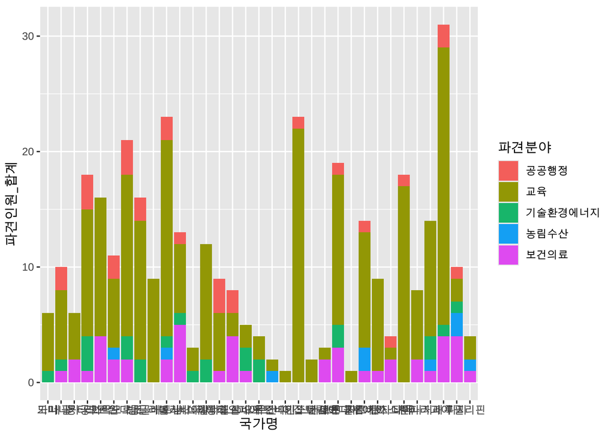

```r
koica_wfk_20260331 |>
  group_by(국가명, 파견분야) |>
  reframe(파견인원_합계 = sum(인원)) |>
  ggplot(aes(x = 국가명, y = 파견인원_합계, fill = 파견분야)) +
  geom_bar(stat = 'identity')
```

```r
koica_wfk_20260331 |>
  group_by(국가명, 파견분야) |>
  reframe(파견인원_합계 = sum(인원)) |>
  ggplot(aes(x = 국가명, y = 파견인원_합계, fill = 파견분야)) +
  geom_bar(stat = 'identity') +
  coord_flip()
```

[output not shown]

### 5.7.2 group_by() + geom_tile()

> 국가별 파견분야별 파견인원을 히트맵을 그립니다.

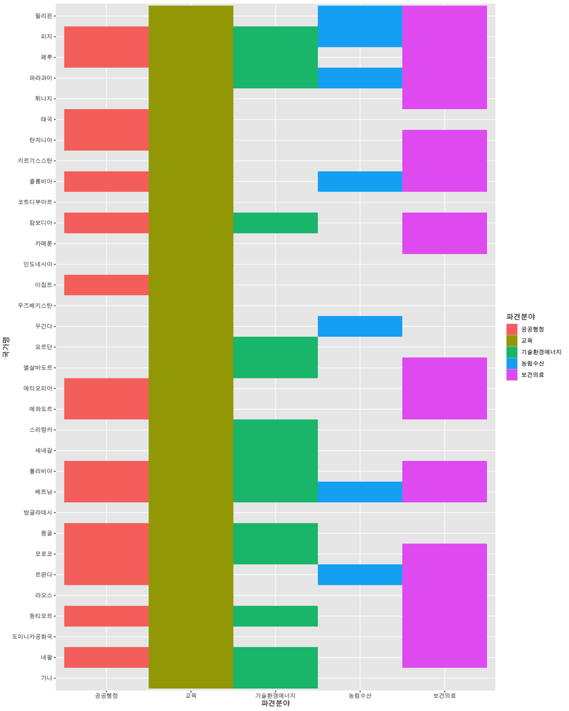

```r
koica_wfk_20260331 |>
  group_by(국가명, 파견분야) |>
  reframe(파견인원_합계 = sum(인원)) |>
  ggplot(aes(x = 파견분야, y = 국가명, fill = 파견분야)) +
  geom_tile()
```

### 5.7.3 geom_text() + theme_minimal()

> 데이터를 선별하고, 히트맵을 예쁘게 꾸며줍니다.

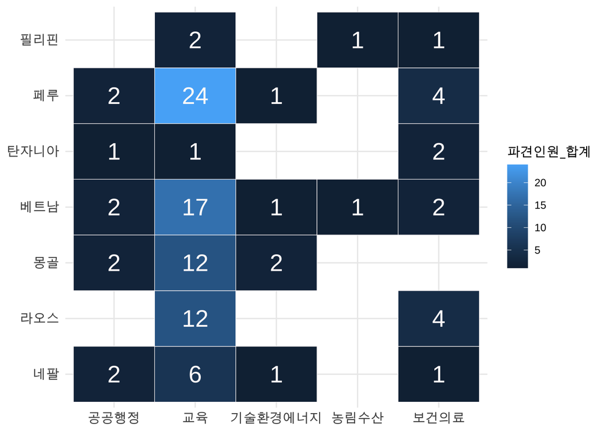

```r
koica_wfk_20260331 |>
  group_by(국가명, 파견분야) |>
  reframe(파견인원_합계 = sum(인원)) |>
  filter(국가명 %in% c("페루", "라오스", "몽골","네팔",
                    "탄자니아", "베트남", "필리핀")) |>
  ggplot(aes(x = 파견분야, y = 국가명, fill = 파견인원_합계)) +
  geom_tile(color = 'snow') +
  geom_text(aes(label = 파견인원_합계), color = 'snow', size = 7) +
  theme_minimal() +
  theme(axis.title = element_blank(),
        axis.text = element_text(size = 11))
```

### 5.7.4 히스토그램

> 파견인원 분포

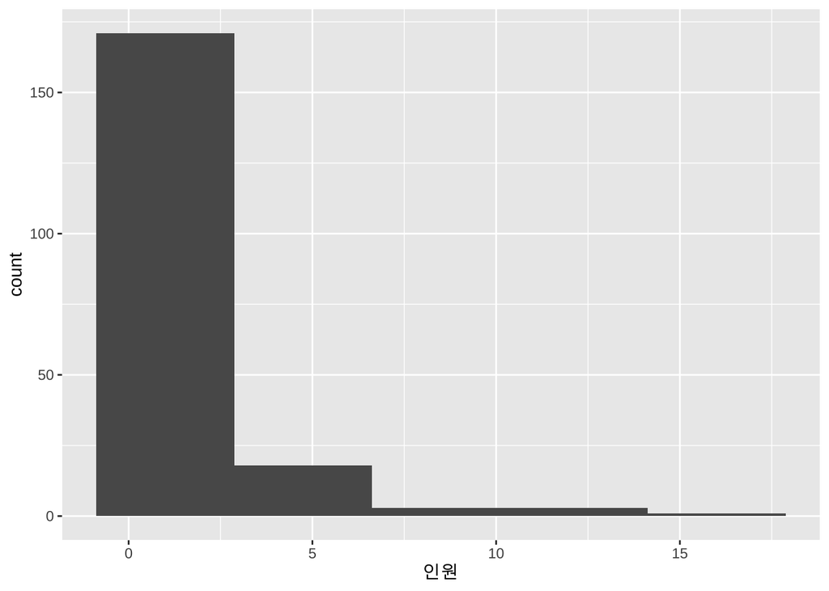

```r
koica_wfk_20260331 |>
  ggplot(aes(x = 인원)) +
  geom_histogram(bins = 5)
```

#### geom_histogram(binwidth = 1)

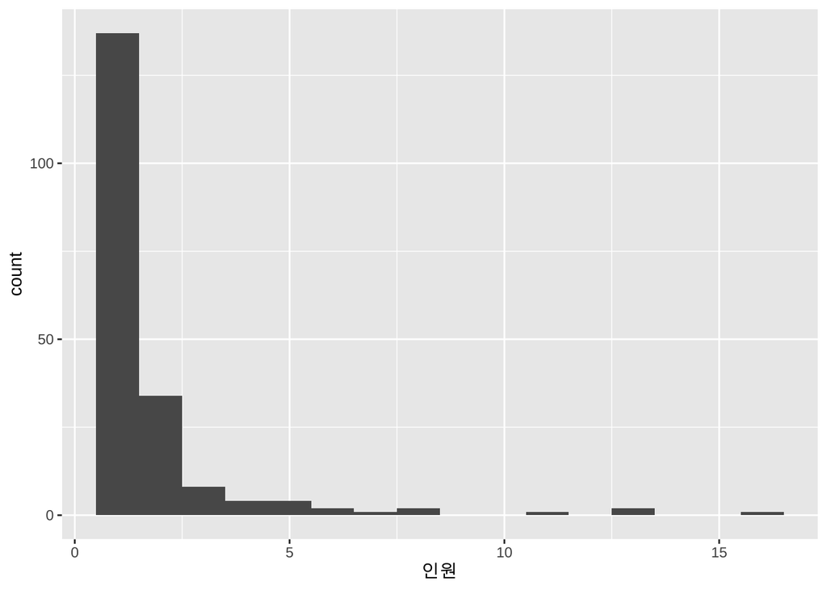

```r
koica_wfk_20260331 |>
  ggplot(aes(x = 인원)) +
  geom_histogram(binwidth = 1)
```